# Course Project for Machine Learning

Canqing YU

Sunday, July 27, 2014

This is the course project for *Practical Machine Learning* in data science specialization. The *Weight Lifting Exercise Dataset* for this project come from this source: http://groupware.les.inf.puc-rio.br/har.

#### Read in data

First of all, read in the training and testing dataset.

```r
setwd("K:/MOOCs - Data Science Specialization/8. Practical Machine Learning/Writeup")
if (!file.exists("pml-training.csv")){download.file("https://d396qusza40orc.cloudfront.net/predmachlearn/pml-training.csv", destfile="pml-training.csv", method="curl")}
if (!file.exists("pml-testing.csv")){download.file("https://d396qusza40orc.cloudfront.net/predmachlearn/pml-testing.csv", destfile="pml-testing.csv", method="curl")}
training <- read.csv("pml-training.csv")
testing <- read.csv("pml-testing.csv")
```

#### Data exploration

Preliminary data cleaning and exploration:

- delete the `NA` variables
- delete the variables which have a large proportion of empty values
- delete irrelevant variables

```r
dim(training)
```

```
## [1] 19622   160
```

```r
dim(testing)
```

```
## [1]  20 160
```

```r
clean1 <- training[,!apply(training,2,anyNA)] #delete NA columns
clean2 <- clean1[,apply(clean1,2,function(x){sum(x=='')==0})] #delete empty columns
clean3 <- clean2[,-(1:7)] #remove irrelarent variables
colnames(clean3)
```

```
##  [1] "roll_belt"            "pitch_belt"           "yaw_belt"
##  [4] "total_accel_belt"     "gyros_belt_x"         "gyros_belt_y"
##  [7] "gyros_belt_z"         "accel_belt_x"         "accel_belt_y"
## [10] "accel_belt_z"         "magnet_belt_x"        "magnet_belt_y"
## [13] "magnet_belt_z"        "roll_arm"             "pitch_arm"
## [16] "yaw_arm"              "total_accel_arm"      "gyros_arm_x"
## [19] "gyros_arm_y"          "gyros_arm_z"          "accel_arm_x"
## [22] "accel_arm_y"          "accel_arm_z"          "magnet_arm_x"
## [25] "magnet_arm_y"         "magnet_arm_z"         "roll_dumbbell"
## [28] "pitch_dumbbell"       "yaw_dumbbell"         "total_accel_dumbbell"
## [31] "gyros_dumbbell_x"     "gyros_dumbbell_y"     "gyros_dumbbell_z"
## [34] "accel_dumbbell_x"     "accel_dumbbell_y"     "accel_dumbbell_z"
## [37] "magnet_dumbbell_x"    "magnet_dumbbell_y"    "magnet_dumbbell_z"
## [40] "roll_forearm"         "pitch_forearm"        "yaw_forearm"
## [43] "total_accel_forearm"  "gyros_forearm_x"      "gyros_forearm_y"
## [46] "gyros_forearm_z"      "accel_forearm_x"      "accel_forearm_y"
## [49] "accel_forearm_z"      "magnet_forearm_x"     "magnet_forearm_y"
## [52] "magnet_forearm_z"     "classe"
```

#### Split data

Split the `training` data set into `train` and `test` data sets, with the proportions of 60% and 40%. So we could estimate the out-of-sample error.

```r
suppressPackageStartupMessages(library(caret))
set.seed(20140727)
inTrain <- createDataPartition(y=clean3$classe, p=0.6, list=FALSE)
train <- clean3[inTrain,]
test <- clean3[-inTrain,]
```

#### Model fitting

In order to boost the process of computing, `doParallel` package was used to create a cluster for multiple cores. As for the model fitting, `caret` package was used to apply the `random forest` method to train the machine learning algorithm.

```r
suppressPackageStartupMessages(library(caret))
suppressPackageStartupMessages(library(doParallel))
cl<-makeCluster(6)
registerDoParallel(cl)
fitControl <- trainControl(method='cv', number=3)
modFit <- train(classe~., method='rf', trControl=fitControl, data=train)
stopCluster(cl)
```

#### Cross validation

```r
pred_train <- predict(modFit, newdata=train[,-53])
confusionMatrix(pred_train, train$classe)
```

```
## Confusion Matrix and Statistics
##
##           Reference
## Prediction    A    B    C    D    E
##          A 3348    0    0    0    0
##          B    0 2279    0    0    0
##          C    0    0 2054    0    0
##          D    0    0    0 1930    0
##          E    0    0    0    0 2165
##
## Overall Statistics
##
##                Accuracy : 1
##                  95% CI : (1, 1)
##     No Information Rate : 0.284
##     P-Value [Acc > NIR] : <2e-16
##
##                   Kappa : 1
##  Mcnemar's Test P-Value : NA
##
## Statistics by Class:
##
##                      Class: A Class: B Class: C Class: D Class: E
## Sensitivity             1.000    1.000    1.000    1.000    1.000
## Specificity             1.000    1.000    1.000    1.000    1.000
## Pos Pred Value          1.000    1.000    1.000    1.000    1.000
## Neg Pred Value          1.000    1.000    1.000    1.000    1.000
## Prevalence              0.284    0.194    0.174    0.164    0.184
## Detection Rate          0.284    0.194    0.174    0.164    0.184
## Detection Prevalence    0.284    0.194    0.174    0.164    0.184
## Balanced Accuracy       1.000    1.000    1.000    1.000    1.000
```

```r
pred_test <- predict(modFit, newdata=test[,-53])
confusionMatrix(pred_test, test$classe)
```

```
## Confusion Matrix and Statistics
##
##           Reference
## Prediction    A    B    C    D    E
##          A 2231   13    0    0    0
##          B    0 1499   15    0    3
##          C    0    4 1344   14    4
##          D    0    2    9 1271   12
##          E    1    0    0    1 1423
##
## Overall Statistics
##
##                Accuracy : 0.99
##                  95% CI : (0.988, 0.992)
##     No Information Rate : 0.284
##     P-Value [Acc > NIR] : <2e-16
##
##                   Kappa : 0.987
##  Mcnemar's Test P-Value : NA
##
## Statistics by Class:
##
##                      Class: A Class: B Class: C Class: D Class: E
## Sensitivity             1.000    0.987    0.982    0.988    0.987
## Specificity             0.998    0.997    0.997    0.996    1.000
## Pos Pred Value          0.994    0.988    0.984    0.982    0.999
## Neg Pred Value          1.000    0.997    0.996    0.998    0.997
## Prevalence              0.284    0.193    0.174    0.164    0.184
## Detection Rate          0.284    0.191    0.171    0.162    0.181
## Detection Prevalence    0.286    0.193    0.174    0.165    0.182
## Balanced Accuracy       0.999    0.992    0.990    0.992    0.993
```

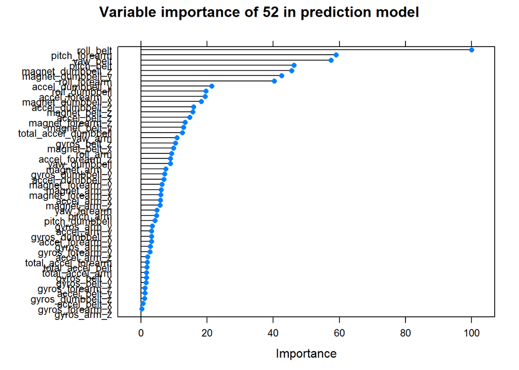

```r
plot(varImp(modFit), main="Variable importance of 52 in prediction model")
```

From the variable importance plot, we could see the `roll_belt` is most important variable.

#### Prediction with test data set

Apply the algorithm generated from `training` data set by the machine learning model, we could predict the 20 samples in the `testing` data set.

```r
answers <- as.character(predict(modFit, testing))
answers
```

```
##  [1] "B" "A" "B" "A" "A" "E" "D" "B" "A" "A" "B" "C" "B" "A" "E" "E" "A"
## [18] "B" "B" "B"
```